# Chapter 4

```r
#Reload the scaled dataset:
boston_scaled <- read.table("https://raw.githubusercontent.com/KimmoVehkalahti/Helsinki-Open-Data-Science/master/datasets/boston_scaled.txt",
                            sep=",", header = T)

# Rename the categories
boston_scaled$crime <- factor(boston_scaled$crime, levels = c("low", "med_low", "med_high", "high"))

# number of rows in the Boston dataset
n <- nrow(boston_scaled)

# choose randomly 80% of the rows
ind <- sample(n,  size = n * 0.8)

# create train set
train <- boston_scaled[ind,]

# create test set
test <- boston_scaled[-ind,]

# save the correct classes from test data
correct_classes <- test$crime

# remove the crime variable from test data
test <- dplyr::select(test, -crime)

#summaries

str(train)
```

```
## 'data.frame':    404 obs. of  14 variables:
##  $ zn     : num  -0.487 -0.487 -0.487 0.37 -0.487 ...
##  $ indus  : num  1.015 -0.8668 1.015 -1.0447 -0.0797 ...
##  $ chas   : num  -0.272 -0.272 -0.272 -0.272 3.665 ...
##  $ nox    : num  1.366 -0.343 1.254 0.797 -0.567 ...
##  $ rm     : num  0.0461 -0.5916 -1.0883 0.7933 -1.3388 ...
##  $ age    : num  0.512 -0.791 1.116 1.116 1.116 ...
##  $ dis    : num  -0.504 0.682 -1.074 -0.847 0.038 ...
##  $ rad    : num  1.66 -0.522 1.66 -0.522 -0.637 ...
##  $ tax    : num  1.529 -1.093 1.529 -0.856 -0.779 ...
##  $ ptratio: num  0.8058 0.8058 0.8058 -2.5199 0.0667 ...
##  $ black  : num  0.441 0.441 0.441 0.386 0.441 ...
##  $ lstat  : num  0.187 -0.4 1.667 -0.806 1.462 ...
##  $ medv   : num  -0.33 -0.33 -1.113 0.823 -0.275 ...
##  $ crime  : Factor w/ 4 levels "low","med_low",..: 4 1 4 3 3 3 3 1 2 3 ...
```

```r
str(test)
```

```
## 'data.frame':    102 obs. of  13 variables:
##  $ zn     : num  -0.4872 0.0487 0.0487 -0.4872 -0.4872 ...
##  $ indus  : num  -1.306 -0.476 -0.476 -0.437 -0.437 ...
##  $ chas   : num  -0.272 -0.272 -0.272 -0.272 -0.272 ...
##  $ nox    : num  -0.834 -0.265 -0.265 -0.144 -0.144 ...
##  $ rm     : num  1.015 -0.399 0.131 -0.268 -0.498 ...
##  $ age    : num  -0.809 0.615 0.914 0.566 -1.395 ...
##  $ dis    : num  1.077 1.328 1.212 0.317 0.334 ...
##  $ rad    : num  -0.752 -0.522 -0.522 -0.637 -0.637 ...
##  $ tax    : num  -1.105 -0.577 -0.577 -0.601 -0.601 ...
##  $ ptratio: num  0.113 -1.504 -1.504 1.175 1.175 ...
##  $ black  : num  0.416 0.329 0.393 0.256 0.331 ...
##  $ lstat  : num  -1.36 0.623 1.092 -0.335 -0.85 ...
##  $ medv   : num  1.1816 -0.395 -0.819 -0.4711 0.0617 ...
```

We now have the training dataset with 404 observation of 14 variables in the training set and 102 observations of 13 variables in the test set, as “crim variable is excluded. Now we will fit the linear discriminant analysis on the train set with the categorical crime rate as target and the other as predictors.

```r
# linear discriminant analysis
lda.fit <- lda(crime ~., data = train)

# print the lda.fit object
lda.fit
```

```
## Call:
## lda(crime ~ ., data = train)
##
## Prior probabilities of groups:
##       low   med_low  med_high      high
## 0.2549505 0.2524752 0.2301980 0.2623762
##
## Group means:
##                  zn      indus         chas        nox         rm        age
## low       0.8854526 -0.8809423 -0.157656245 -0.8569206  0.3462182 -0.8704813
## med_low  -0.1368667 -0.2738403 -0.002135914 -0.5264169 -0.1234419 -0.2141416
## med_high -0.3848883  0.2322204  0.235683866  0.4882196  0.0835892  0.4697125
## high     -0.4872402  1.0170298 -0.049474337  1.0742724 -0.4116986  0.8395261
##                 dis        rad        tax     ptratio       black       lstat
## low       0.8276045 -0.6763567 -0.7296037 -0.35885098  0.37410677 -0.73539625
## med_low   0.2395501 -0.5517590 -0.4500196 -0.05825635  0.32137074 -0.09256389
## med_high -0.4117257 -0.4002282 -0.2728766 -0.29534441  0.03350658  0.05998192
## high     -0.8624748  1.6390172  1.5146914  0.78181164 -0.90283213  0.88000935
##                  medv
## low       0.441908781
## med_low   0.004427816
## med_high  0.114749785
## high     -0.699130517
##
## Coefficients of linear discriminants:
##                 LD1         LD2          LD3
## zn       0.11454747  0.70992411 -0.923508426
## indus    0.03163029 -0.29545304  0.181814679
## chas    -0.09541626 -0.08263053  0.036243095
## nox      0.39709724 -0.62836108 -1.529260337
## rm      -0.09234149 -0.14219142 -0.159445491
## age      0.33183205 -0.38801886  0.006901466
## dis     -0.02413494 -0.30595509  0.014111922
## rad      3.22910563  0.92890587 -0.158472127
## tax     -0.06075524 -0.03148594  0.736568564
## ptratio  0.13384779  0.08555219 -0.301618356
## black   -0.14556873  0.03456981  0.128633932
## lstat    0.19799997 -0.30140446  0.451784875
## medv     0.19127086 -0.39203219 -0.075797980
##
## Proportion of trace:
##    LD1    LD2    LD3
## 0.9494 0.0379 0.0127
```

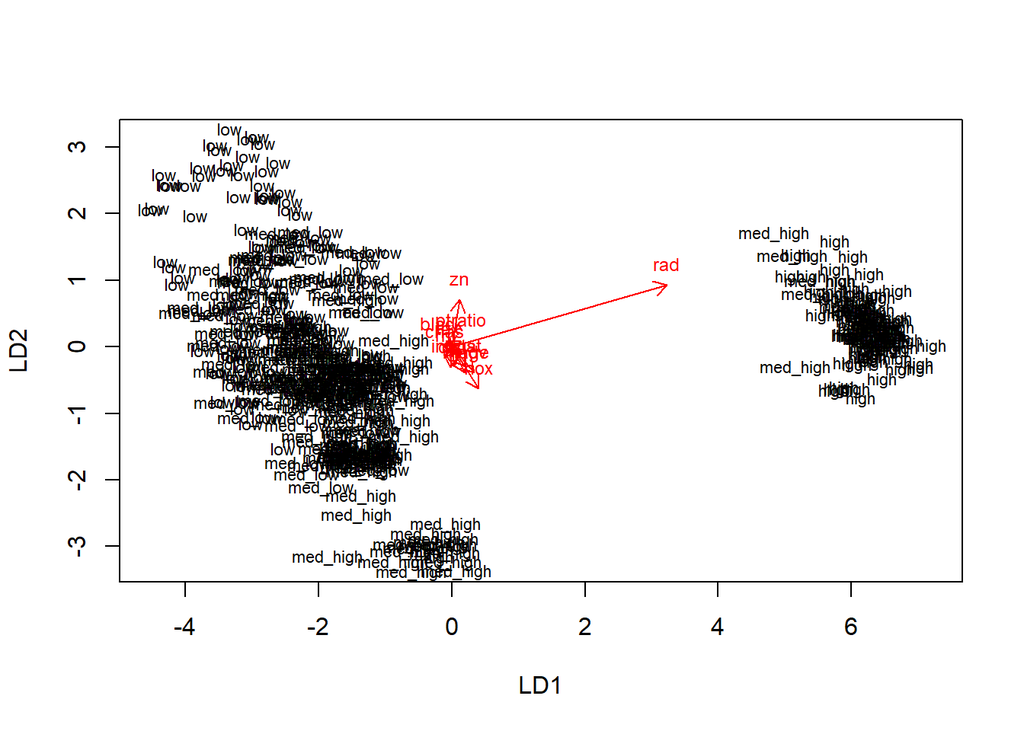

```r
# the function for lda biplot arrows
lda.arrows <- function(x, myscale = 1, arrow_heads = 0.1, color = "red", tex = 0.75, choices = c(1,2)){
  heads <- coef(x)
  graphics::arrows(x0 = 0, y0 = 0,
         x1 = myscale * heads[,choices[1]],
         y1 = myscale * heads[,choices[2]], col=color, length = arrow_heads)
  text(myscale * heads[,choices], labels = row.names(heads),
       cex = tex, col=color, pos=3)
}

# target classes as numeric
classes <- as.numeric(train$crime)

# plot the lda results (select both lines and execute them at the same time!)
plot(lda.fit, dimen = 2)
lda.arrows(lda.fit, myscale = 1)
```

By exploring the console output and generated graph, we can now look at the results of the linear discrimant analysis. The prior probabilities indicate the probability of each group in the training data. In this case, the low, medium low, medium high and high per capita crime rates. The group means represent the mean values of each variable for each group. For example, in the “low” group, the mean values for variables like zn, indus, chas, etc., are provided. **The coefficients of linear discriminants** show the contribution of each variable to the linear combinations used to discriminate between the groups.